# practical machine learning project

Seo-yeon Lim

2018년 3월 31일

## Background

Human Activity Recognition (HAR) has become an interest area for many researchers. Using wearable devices, it is easy to collect data on physical activities, behavior patterns and health issues in a relatively inexpensive manner. Until now, the most popular question that has been asked was “how *much* of a particular activity people do.” Throughout this project, our main goal would be to answer the question of “how *well* they perform particular activity.”

The data used for this project is described in this following link: http://groupware.les.inf.puc-rio.br/har.

6 young healthy participants were asked to perform one set of 10 repetitions of the unilateral dumbell biceps curl in 5 different fashions:

- Class A: exactly according to the specification (correct method)
- Class B: throwing the elbows to the front
- Class C: lifting the dumbbell only halfway
- Class D: lowering the dumbbell only halfway
- Class E: throwing the hips to the front.

## Data Loading and Processing

First, we will load necessary packages for this project.

```r
suppressWarnings(library(caret))
suppressWarnings(library(randomForest))
suppressWarnings(library(rattle))
suppressWarnings(library(dplyr))
```

```r
suppressWarnings(library(ggplot2))
```

We will download and load the training and testing data. Using **dim** function, we can see that there are 160 variables in both of datasets. .

```r
fileurl1 <- "https://d396qusza40orc.cloudfront.net/predmachlearn/pml-training.csv"
download.file(fileurl1, destfile = "./pmltraining.csv")
training <- read.csv("pmltraining.csv")
dim(training)
```

```
## [1] 19622   160
```

```r
fileurl2 <- "https://d396qusza40orc.cloudfront.net/predmachlearn/pml-testing.csv"
download.file(fileurl2, destfile = "./pmltesting.csv")
testing <- read.csv("pmltesting.csv")
dim(testing)
```

```
## [1]  20 160
```

We take a look at the dataset, and we can see that there are numerous columns with NA values and blank values. We will remove these vlaues, as well as zero covariate variables, as those don’t provide much information. Then we will remove the identification variable and timestamps. As a result, we narrowed numbers of variables down to 54.

```r
View(training)
```

```r
NAremove<- sapply(training, function(x) mean(is.na(x))) >0.90
trainingclean <- training[,NAremove==FALSE]

zerocor <- nearZeroVar(trainingclean)
trainingclean <- trainingclean[,-zerocor]
trainingclean <- trainingclean[,-c(1:5)]
```

We do the same for the testing set.

```r
NAremove<- sapply(testing, function(x) mean(is.na(x))) >0.90
testingclean <- testing[,NAremove==FALSE]

zerocor <- nearZeroVar(testingclean)
testingclean <- testingclean[,-zerocor]
testingclean <- testingclean[,-c(1:5)]
```

After some data cleaning, we create a new training dataset.

```r
set.seed(54321)
inTrain <- createDataPartition(trainingclean$classe, p=0.70, list=FALSE)
trainingset <- trainingclean[inTrain, ]
testingset <- trainingclean[-inTrain,]
dim(trainingset)
```

```
## [1] 13737    54
```

```r
dim(testingset)
```

```
## [1] 5885   54
```

## Prediction Modeling

Total three methods of prediction modeling will be applied to the **trainingset**: 1. Decision Trees 2. Random Forest 3. Gradient Boosting method

### 1. Decision Trees

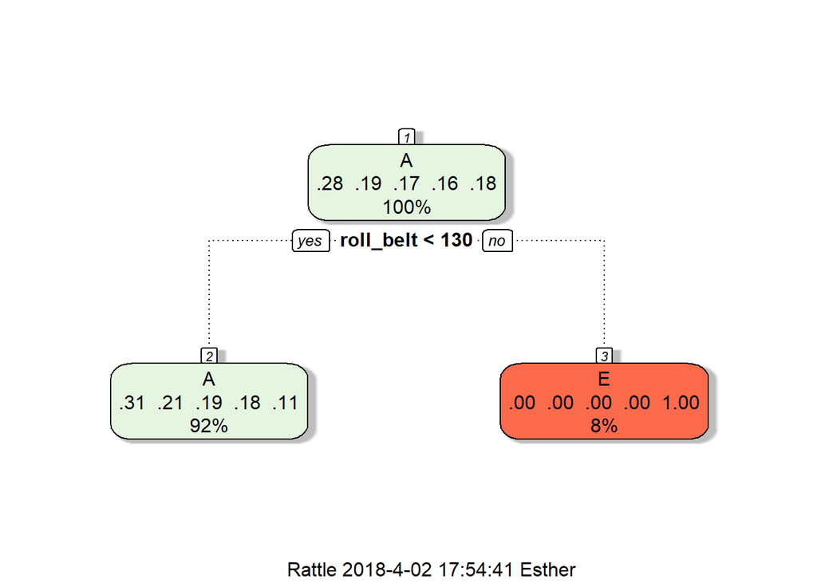

```r
trainctrl <- trainControl(method="cv", number = 5, verboseIter = FALSE)
fit1 <- train(classe~., data=trainingset, method="rpart", trControl=trainctrl)
fancyRpartPlot(fit1$finalModel)
```

```r
predict1 <- predict(fit1, newdata=testingset)
fit1ConfMat <- confusionMatrix(testingset$classe, predict1)
fit1ConfMat
```

```
## Confusion Matrix and Statistics
##
##           Reference
## Prediction    A    B    C    D    E
##          A 1664    0    0    0   10
##          B 1139    0    0    0    0
##          C 1026    0    0    0    0
##          D  964    0    0    0    0
##          E  606    0    0    0  476
##
## Overall Statistics
##
##                Accuracy : 0.3636
##                  95% CI : (0.3513, 0.3761)
##     No Information Rate : 0.9174
##     P-Value [Acc > NIR] : 1
##
##                   Kappa : 0.1209
##  Mcnemar's Test P-Value : NA
##
## Statistics by Class:
##
##                      Class: A Class: B Class: C Class: D Class: E
## Sensitivity            0.3082       NA       NA       NA  0.97942
## Specificity            0.9794   0.8065   0.8257   0.8362  0.88776
## Pos Pred Value         0.9940       NA       NA       NA  0.43993
## Neg Pred Value         0.1130       NA       NA       NA  0.99792
## Prevalence             0.9174   0.0000   0.0000   0.0000  0.08258
## Detection Rate         0.2828   0.0000   0.0000   0.0000  0.08088
## Detection Prevalence   0.2845   0.1935   0.1743   0.1638  0.18386
## Balanced Accuracy      0.6438       NA       NA       NA  0.93359
```

```r
fit1ConfMat$overall[1]
```

```
##  Accuracy
## 0.3636364
```

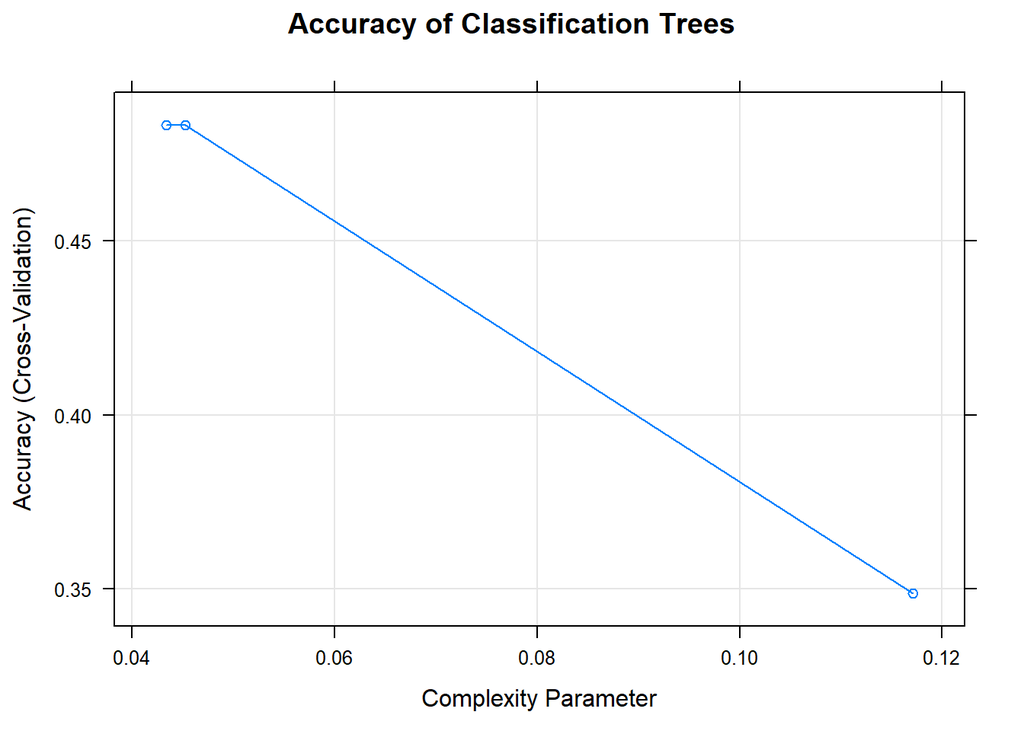

```r
plot(fit1, main= "Accuracy of Classification Trees")
```

### 2. Random Forests

```r
fit2 <- train(classe~., data=trainingset, method="rf", trControl = trainctrl, verbose = FALSE)
fit2$finalModel
```

```
##
## Call:
##  randomForest(x = x, y = y, mtry = param$mtry, verbose = FALSE)
##                Type of random forest: classification
##                      Number of trees: 500
## No. of variables tried at each split: 27
##
##         OOB estimate of  error rate: 0.19%
## Confusion matrix:
##      A    B    C    D    E  class.error
## A 3904    1    0    0    1 0.0005120328
## B    5 2650    3    0    0 0.0030097818
## C    0    6 2390    0    0 0.0025041736
## D    0    0    4 2247    1 0.0022202487
## E    0    1    0    4 2520 0.0019801980
```

```r
predict2 <- predict(fit2, newdata=testingset)
fit2ConfMat <- confusionMatrix(testingset$classe, predict2)
fit2ConfMat
```

```
## Confusion Matrix and Statistics
##
##           Reference
## Prediction    A    B    C    D    E
##          A 1674    0    0    0    0
##          B    1 1136    2    0    0
##          C    0    1 1025    0    0
##          D    0    0    3  961    0
##          E    0    0    0    2 1080
##
## Overall Statistics
##
##                Accuracy : 0.9985
##                  95% CI : (0.9971, 0.9993)
##     No Information Rate : 0.2846
##     P-Value [Acc > NIR] : < 2.2e-16
##
##                   Kappa : 0.9981
##  Mcnemar's Test P-Value : NA
##
## Statistics by Class:
##
##                      Class: A Class: B Class: C Class: D Class: E
## Sensitivity            0.9994   0.9991   0.9951   0.9979   1.0000
## Specificity            1.0000   0.9994   0.9998   0.9994   0.9996
## Pos Pred Value         1.0000   0.9974   0.9990   0.9969   0.9982
## Neg Pred Value         0.9998   0.9998   0.9990   0.9996   1.0000
## Prevalence             0.2846   0.1932   0.1750   0.1636   0.1835
## Detection Rate         0.2845   0.1930   0.1742   0.1633   0.1835
## Detection Prevalence   0.2845   0.1935   0.1743   0.1638   0.1839
## Balanced Accuracy      0.9997   0.9992   0.9975   0.9987   0.9998
```

```r
fit2ConfMat$overall[1]
```

```
##  Accuracy
## 0.9984707
```

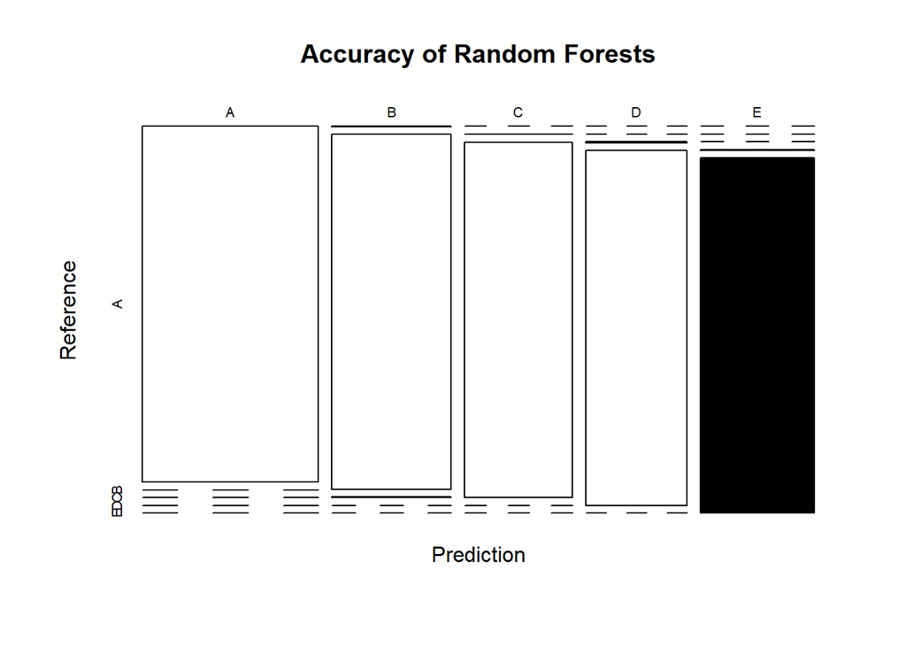

```r
plot(fit2ConfMat$table, col=fit2ConfMat$byClass, main= "Accuracy of Random Forests")
```

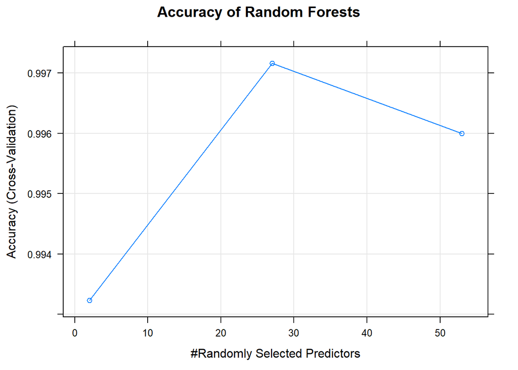

```r
plot(fit2, main= "Accuracy of Random Forests")
```

The accuracy for random forests model was high, about 99.8%. We can also see in the plot that somewhat between 25 to 30 randomly selected predictors have the highest accuracy.

### 3. Gradient Boosting Method

```r
fit3 <- train(classe~., data=trainingset, method="gbm", trControl= trainctrl, verbose= FALSE)
fit3$finalModel
```

```
## A gradient boosted model with multinomial loss function.
## 150 iterations were performed.
## There were 53 predictors of which 42 had non-zero influence.
```

```r
predict3 <- predict(fit3, newdata=testingset)
fit3ConfMat <- confusionMatrix(testingset$classe, predict3)
fit3ConfMat
```

```
## Confusion Matrix and Statistics
##
##           Reference
## Prediction    A    B    C    D    E
##          A 1664   10    0    0    0
##          B    7 1116   13    3    0
##          C    0   11 1012    3    0
##          D    1    6    8  947    2
##          E    1    7    3    9 1062
##
## Overall Statistics
##
##                Accuracy : 0.9857
##                  95% CI : (0.9824, 0.9886)
##     No Information Rate : 0.2843
##     P-Value [Acc > NIR] : < 2.2e-16
##
##                   Kappa : 0.9819
##  Mcnemar's Test P-Value : NA
##
## Statistics by Class:
##
##                      Class: A Class: B Class: C Class: D Class: E
## Sensitivity            0.9946   0.9704   0.9768   0.9844   0.9981
## Specificity            0.9976   0.9951   0.9971   0.9965   0.9959
## Pos Pred Value         0.9940   0.9798   0.9864   0.9824   0.9815
## Neg Pred Value         0.9979   0.9928   0.9951   0.9970   0.9996
## Prevalence             0.2843   0.1954   0.1760   0.1635   0.1808
## Detection Rate         0.2828   0.1896   0.1720   0.1609   0.1805
## Detection Prevalence   0.2845   0.1935   0.1743   0.1638   0.1839
## Balanced Accuracy      0.9961   0.9828   0.9870   0.9905   0.9970
```

```r
fit3ConfMat$overall[1]
```

```
##  Accuracy
## 0.9857264
```

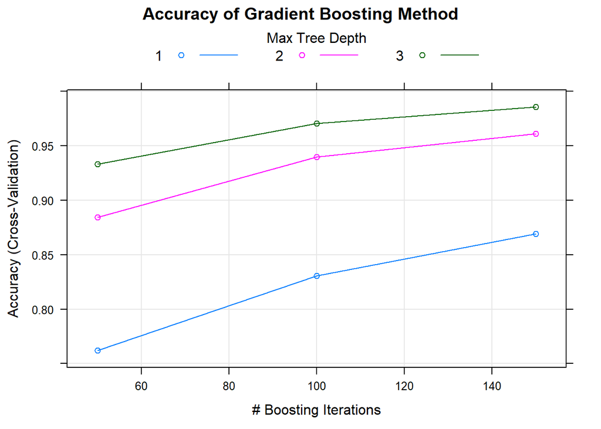

```r
plot(fit3, main= "Accuracy of Gradient Boosting Method")
```

## Conclusion

Therefore, random forest will be used to solve quiz problems.

```r
predictquiz <- predict(fit2, newdata=testingclean)
predictquiz
```

```
##  [1] B A B A A E D B A A B C B A E E A B B B
## Levels: A B C D E
```